# IMPACT R user training

# The hypegrammaR Package

## Project plan

Check data cleaning Import data, questionnaire, choices from kobo Merge loops Calculate weights **Calculate results**

## Goal

*Enable people to think more about why they do the analysis and what exactly they want to find out and report on, instead of having to know about or work on how to choose and apply the appropriate summary statistics, hypothesis tests and visualisations.*

## How?

*If each combination of data types, hypothesis types and sampling strategy can be associated uniquely with an appropriate summary statistic, hypothesis test and visualisation we can…*

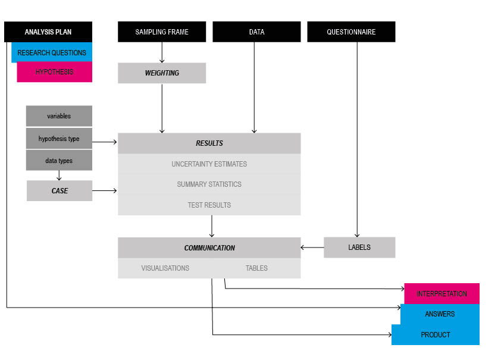

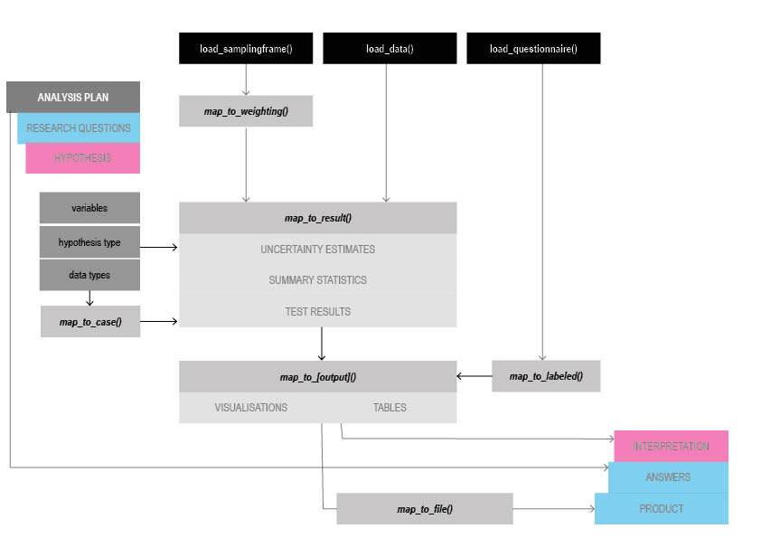

## Exercise install and load hypegrammaR

```r
devtools::install_github("ellieallien/hypegrammaR", build_opts = c())

library(hypegrammaR)

browseVignettes("hypegrammaR")
```

See if there is a difference on problems accessing latrines depending on the gender of the head of household

# DAY 4

## SESSION 3.1.1: grand finale

- chamapgne

## SESSION 3.2.2: BONUS SESSION

- rmarkdown: the gold standard of reproducible data science
- custom functions / building tools for yourself